# Project.Final

Leslie Speight Youtsey and Liz Weatherup

11/13/2020

# Title: Fluxes in the ocean

# Abstract:

# Introduction:

Many environmental and anthropogenic activities can affect the amount of nutrient runoff into water ecosystems (1). The amount of nitrogen (N) and phosphorus (P) entering an ecosystem can affect their flux as well as many other environmental impacts (1). In a study done in Erhai Lake, it showed that nitrogen and phosphorus diffusion flux can affect the biomass and population of autotrophs in this lake that can result in algal blooms (2). We can expect a similar trend to happen in the ocean, but due to the open oceans variability, it is much easier to study these trends in a lake system. Nitrogen and phosphorus fluxes are influenced by internal and external factors such as: nutritive salt concentration, DO, pH, algal biomass, microbial activity, chlorophyll a, etc. (2). It is important to look at these controlling factors and how they will affect the fluxes and the ecosystem as a whole. For example, Erhai Lake is in a transition phase from mesotrophic to eutrophic bodies of water due to the increase of nutritive salts affecting the N and P diffusive fluxes (2).

Carbon also enters the ocean and causes stress to organisms as it increases ocean acidity, but it enters through the earth’s atmosphere (3). The amount of carbon in the atmosphere has been steadily increasing overtime due to the large input of fossil fuels into the environment (3). Again, carbon input, like nitrogen and phosphorus is caused by anthropogenic stress.

Nitrogen, phosphorus, and carbon are all connected in that they relate to the biological pump and the solubility pump. They all interact with marine organisms that use them for growth and energy, and they are eventually respired or excreted out of these organisms to sink to depth (4). Ocean physics and the solubility pump also helps to aid these to sink to depth, especially in areas of deep, cold water mixing, like the Southern Ocean (4). The sinking of this nitrogen, phosphorus, and carbon is flux (4). These fluxes are important, especially when it comes to carbon sequestration, which has often been a hot topic as a way to decrease the amount of carbon in the atmosphere. Typically, these fluxes tend to decrease with depth due to the carbon, phosphorus, and nitrogen being used by organisms along the way down to the benthos (4).

The best way to measure these fluxes is using sediment traps. Sediments traps are a method for collecting and determining the sinking fluxes of particulate matter, carbon, and nitrogen in the sea. These values are expressed as mg m^-2 day^-1. Total particulate mass flux is defined as the amount of sinking particulate matter passing through a depth level as ( mg dry weight m^-2 day^-2). Total particulate carbon flux is defined as the amount of sinking particulate organic carbon passing through a depth level (mg carbon m^-2 day^-1). Total nitrogen mass flux is defined as the amount of sinking particulate organic nitrogen passing through a depth level (mg nitrogen m^-2 day^-1) (5).

In our study we looked at fluxes of nitrogen, phosphorus, carbon, and mass in the Bermuda Atlantic Time-series through The Joint Global Ocean Flux Study. The Joint Global Ocean FLux Study (JGOFS) is a multi-disciplinary and international study that aims to understand the ocean’s role in global carbon and nutrient cycles. One of the objectives of the U.S JGOFS- sponsored Bermuda Atlantic Time-series Study (BATS) is to “observe and interpret the annual and interannual variability in the rates of particle flux and the apparent rates of particle remineralization over the entire water column”. BATS began in October 1988 and is through December 2016.(6)

Our objectives include evaluating how depth affects each flux and how each flux affects mass flux.

# Toolbox discussion:

Over the course of MSCI 504, we learn key statistical topics and skills, including, but not limited too, statistical inference, distributional assumption and rational, confidence intervals, hypothesis testing, linear and multiple regression, analysis of variance (ANOVA), and analysis of covariance (ANCOVA). All of these course topics are included in this project. Our data included the values of carbon, nitrogen, phosphorus, and mass flux sampled at various depths along multiple cruises. The mean and standard deviation of each flux at each depth was taken. To analyze the structure and distribution of our sample, histograms and boxplots were made. Hypothesis testing in the form of paired sample t-test. Linear and multiple regression was performed to predict mass flux. An ANOVA test was performed to compare large vs small models. An ANCOVA model was done to take into account covariance and blocking factors within our data.

# Description:

# Implementation:

*See Appendix for all code*

### Reading csv data in

Here is what our data looks like

|  | cr | dep | yymmdd1 | yymmdd2 | Lat2 | Lat2.1 | Long1 | Long2 | M_avg | C_avg | N_avg | P_avg |
| --- | --- | --- | --- | --- | --- | --- | --- | --- | --- | --- | --- | --- |
| 605 | 10205 | 150 | 20051010 | 20051014 | 31.596 | 31.616 | 64.164 | 64.161 | 64.99 | 14.35 | 2.39 | 0.0022 |
| 606 | 10205 | 200 | 20051010 | 20051014 | 31.596 | 31.616 | 64.164 | 64.161 | 43.24 | 11.26 | 1.89 | 0.0023 |
| 607 | 10205 | 300 | 20051010 | 20051014 | 31.596 | 31.616 | 64.164 | 64.161 | 47.75 | 9.55 | 1.33 | 0.0007 |
| 608 | 10206 | 150 | 20051124 | 20051126 | 31.578 | 31.479 | 64.180 | 64.157 | 48.27 | 15.09 | 2.66 | 0.0042 |
| 609 | 10206 | 200 | 20051124 | 20051126 | 31.578 | 31.479 | 64.180 | 64.157 | 33.98 | 8.76 | 1.35 | 0.0013 |
| 610 | 10206 | 300 | 20051124 | 20051126 | 31.578 | 31.479 | 64.180 | 64.157 | 32.07 | 7.73 | 0.94 | 0.0007 |

#### Subsetted each flux out seperatly

#### Subsetted each depth and Renaming Columns

### Bar plots to access relationship between fluxes and depths

n values for C-flux at each depth

```
## [1] 314
```

```
## [1] 304
```

```
## [1] 305
```

```
## [1] 18
```

Mean and SE of each depth of C-flux

| Depth | C_flux.Mean | C_flux.SE |
| --- | --- | --- |
| dep150 | 27.17930 | 1.0048090 |
| dep200 | 20.99128 | 1.2497363 |
| dep300 | 14.19941 | 0.5975955 |
| dep400 | 12.15778 | 1.1502888 |

Graph of C-flux

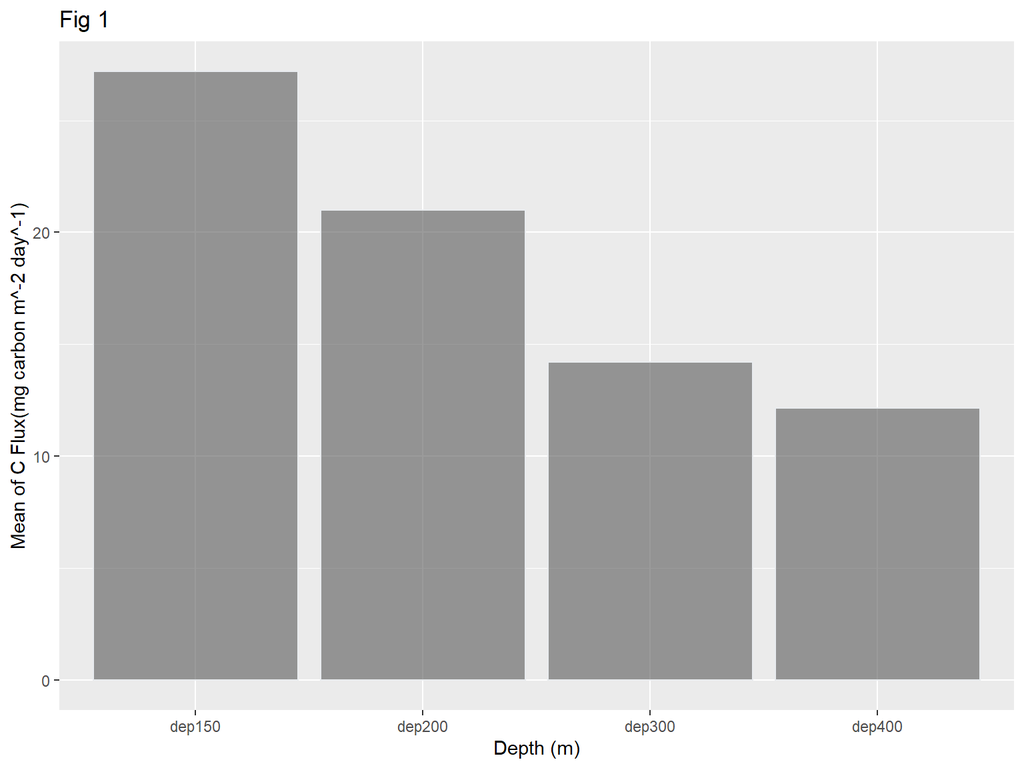

*C-flux decreasing with depth*

n values of P-flux at each depth

```
## [1] 109
```

```
## [1] 106
```

```
## [1] 105
```

```
## [1] 0
```

Mean and SE of each depth of P-flux

| Depth | P_flux.Mean | P_flux.SE |
| --- | --- | --- |
| dep150 | 0.008644037 | 0.001411858 |
| dep200 | 0.006201887 | 0.001151720 |
| dep300 | 0.003866667 | 0.000852678 |

Graph of P-flux

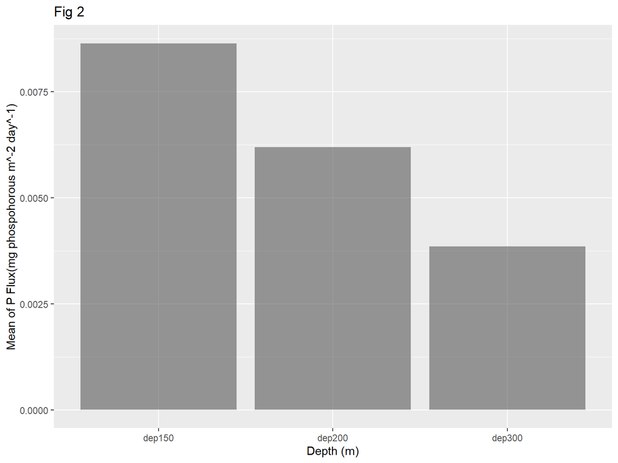

*P-flux decreaing with depth*

n value of N-flux at each depth

```
## [1] 312
```

```
## [1] 302
```

```
## [1] 303
```

```
## [1] 18
```

Mean and SE of each depth of N-flux

| Depth | N_flux.Mean | N_flux.SE |
| --- | --- | --- |
| dep150 | 4.548077 | 0.16714222 |
| dep200 | 3.265960 | 0.15298129 |
| dep300 | 2.055512 | 0.09043535 |
| dep400 | 1.221667 | 0.19282938 |

Graph of N-flux

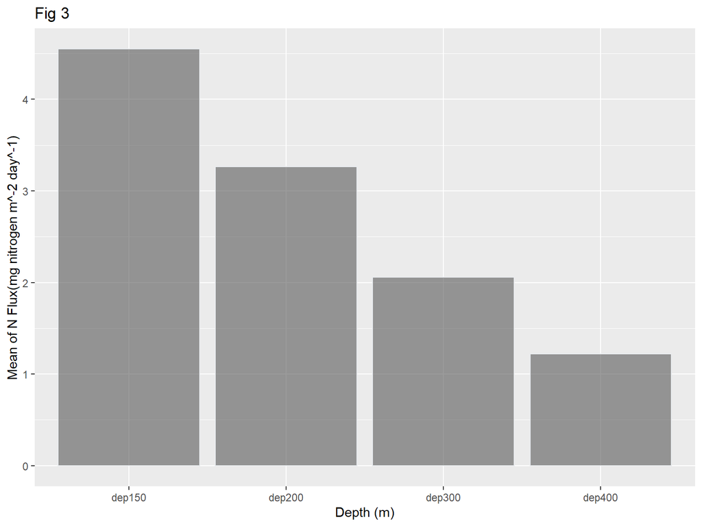

*N-flux decreasing with depth*

n value for M-flux at each depth

```
## [1] 314
```

```
## [1] 305
```

```
## [1] 305
```

```
## [1] 17
```

Mean and SE of each depth of M-flux

| Depth | M_flux.Mean | M_flux.SE |
| --- | --- | --- |
| dep150 | 126.28223 | 6.450246 |
| dep200 | 108.07770 | 7.316204 |
| dep300 | 79.17462 | 4.341316 |
| dep400 | 64.18529 | 4.928044 |

Graph of M-flux

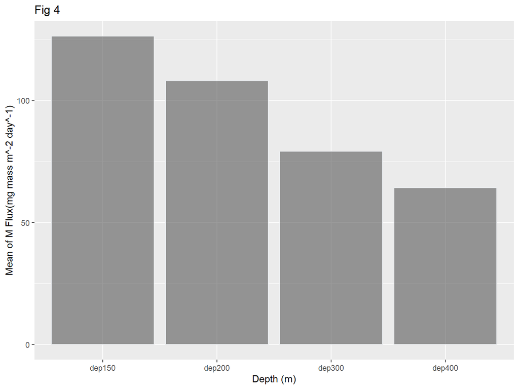

*M-flux decreasing with depth*

### Distributionand box plot of our data by depth

Checking for normality and outliers in flux distribution

Log transfromation was needed for all Fluxes

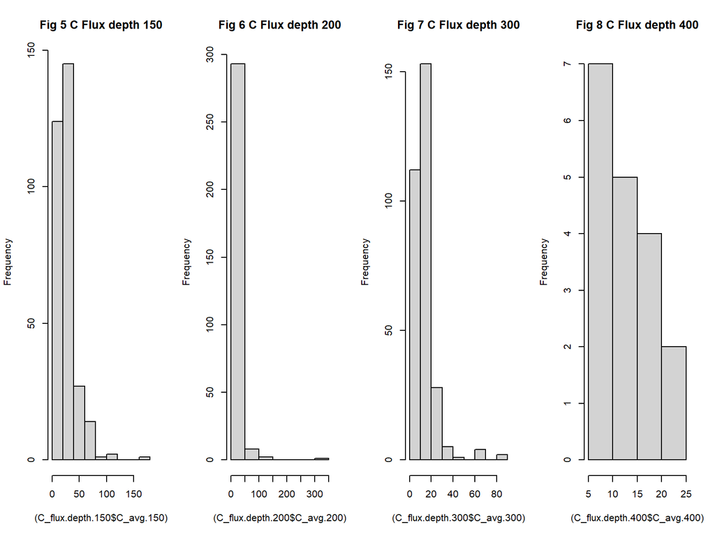

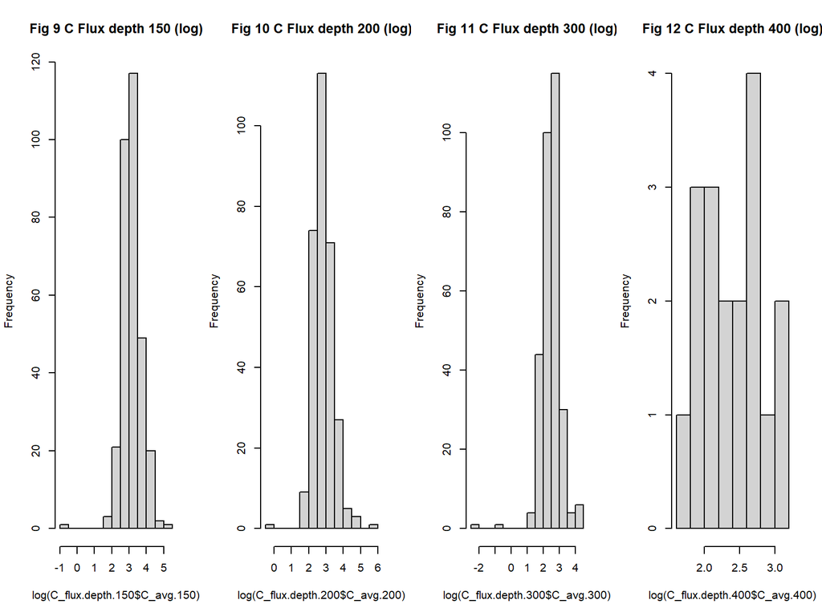

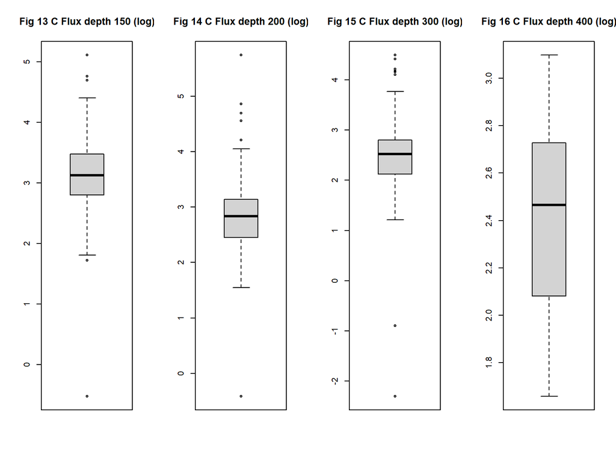

*boxplot means do not overlap, but box sizes for 150, 200, and 300 seem to be similar in box size as well as whisker length which means that they could be good predictors of each other and do not break homoscedasticity. However, the 400 depth has a lot of overlap and a very different shape which could break homosedasticity*

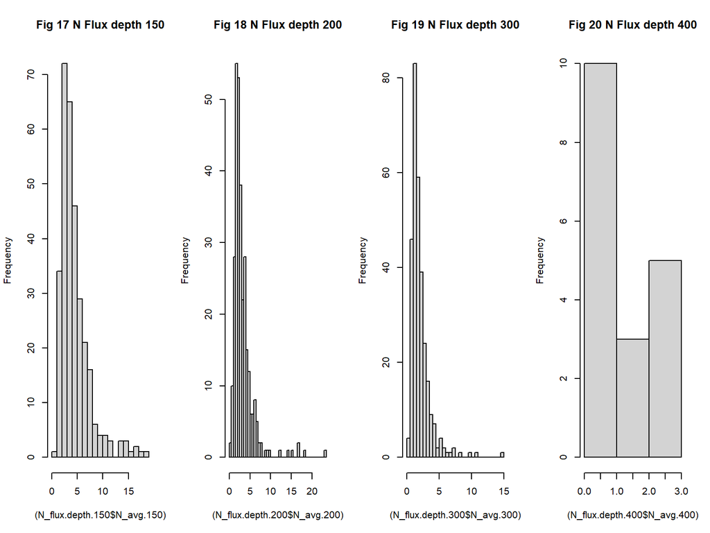

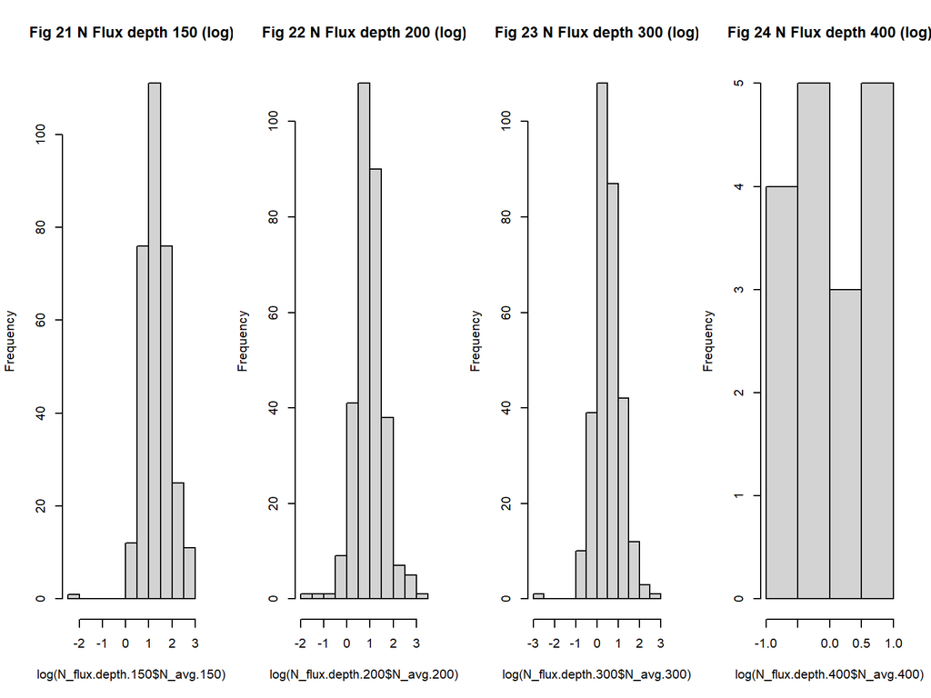

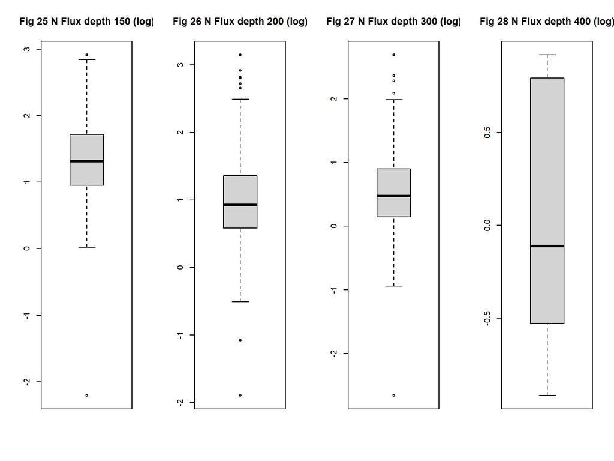

*boxplot means do not too seem to overlab too much for 150 and 200, but ther is a bit of overlap in 200 and 300. 150, 200, and 300 seem to be similar in box size as well as whisker length which means that they could be good predictors of each other and do not break homoscedasticity. However, the 400 depth has a lot of overlap and a very different shape which could break homosedasticity*

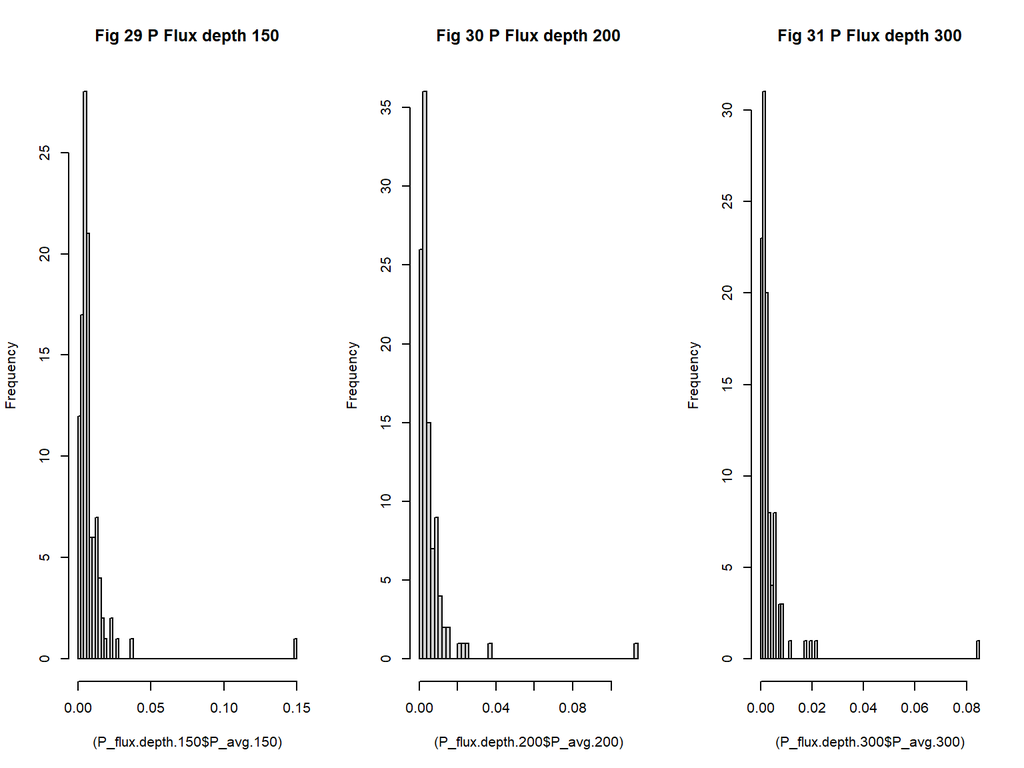

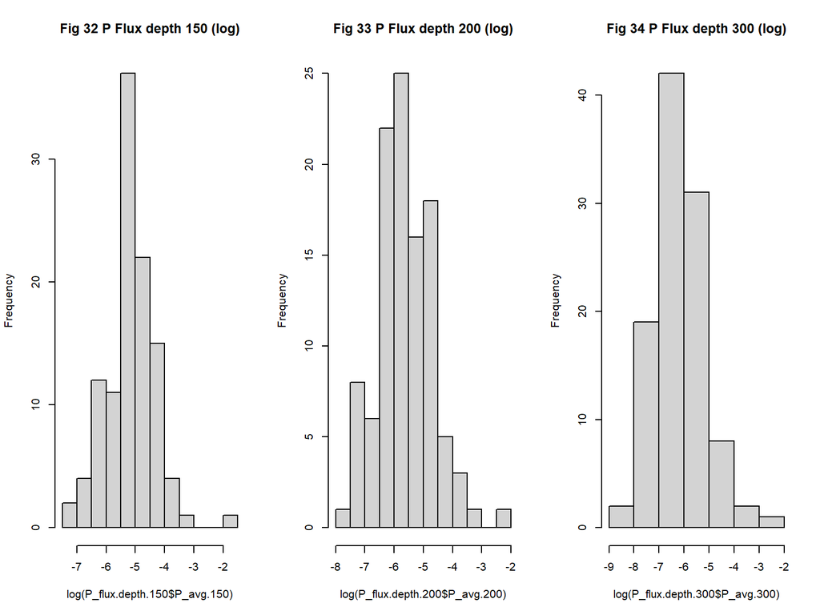

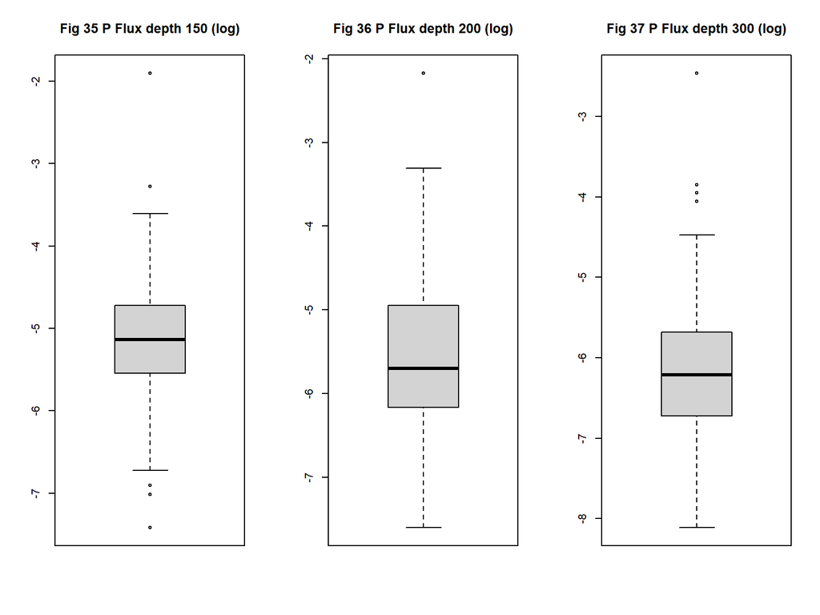

*boxplot means seem to have some overlap. They are similar in box size, but the concern is the overlap, making them not good predictors of one another and potentially breaking homosedasticity*

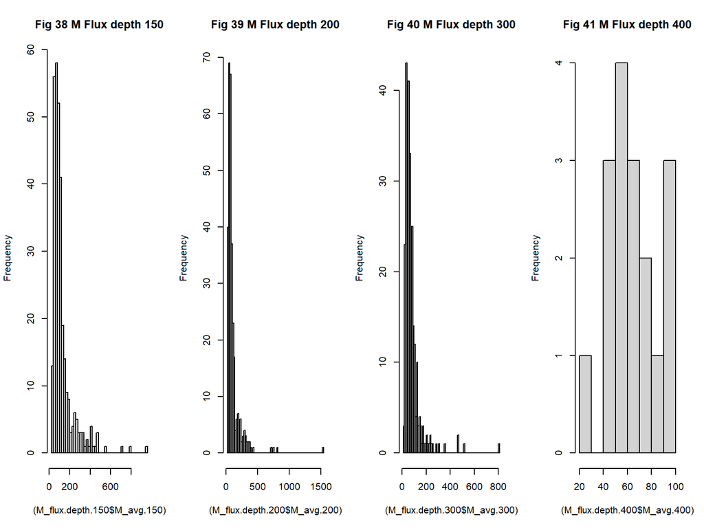

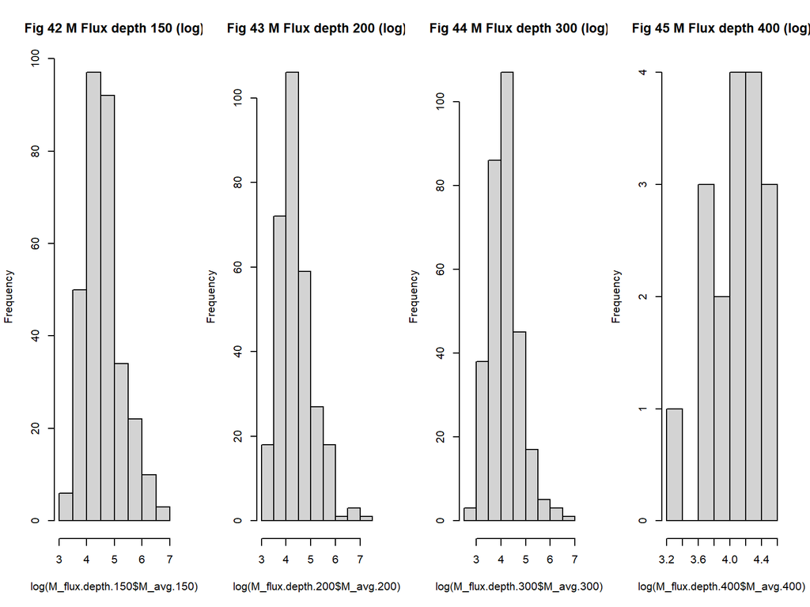

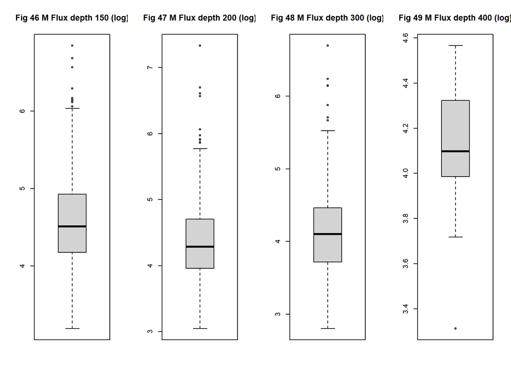

*boxplot means seem to have some overlap. They are similar in box size, but the concern is the overlap, making them not good predictors of one another and potentially breaking homosedasticity*

*Since many of the 400 m depth distrubutions were not normal, even after transformation and have small n, they will not be used in the hypothesis testing*

### Paired sample t test for each depth and the depth below it

This is a paired test because samples were collected on the same cruise and at the same location. So for each flux value at one depth, there was a flux value collected at a different depth at the same location! Data frames were merged based on cruise, year, and location to have the same number of values.

For a paired t test to be preformed it must meet these assumptions:

$\overline{Y_1}$ - $\overline{Y_2}$ = $\overline{D}$

- The dependent variable must be continuous (interval/ratio). $\checkmark$
- The observations are independent of one another. $\checkmark$
- The dependent variable ($\overline{D}$) should be approximately normally distributed. $\Box$ ?
- The dependent variable ($\overline{D}$) should not contain any outliers. $\Box$ ?

Merging data bases for hypothesis test and Creating $\overline{D}$ for each paired group

| Depth.Diff | C_flux | N_flux | P_flux | M_flux |
| --- | --- | --- | --- | --- |
| dep150.200 | 6.188016 | 1.282117 | 0.00244215 | 18.20452 |
| dep200.300 | 6.791873 | 1.210449 | 0.00233522 | 28.90308 |

Checking the distribution of the $\overline{D}$ for each flux

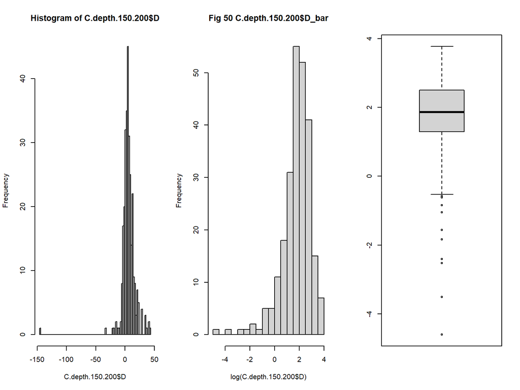

*Cdepth (150.200) is not very normal, but log transformation increases normality. Outliers present in box plot*

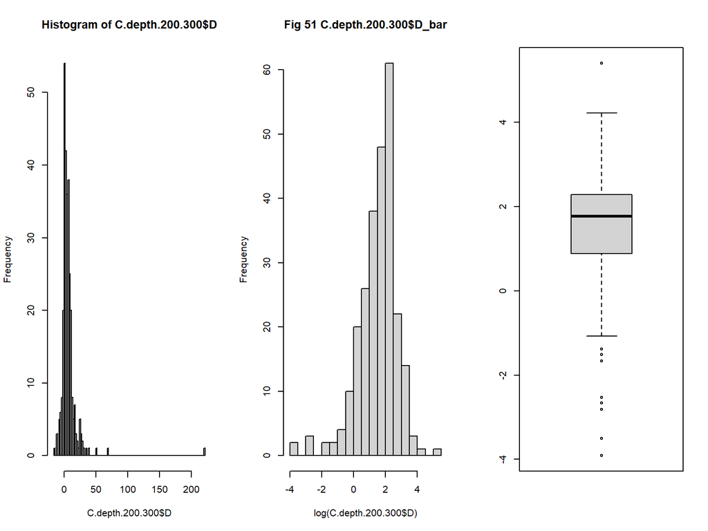

*Cdepth (200.300) is not normal, but log transformation increases normality. Outliers present in box plot*

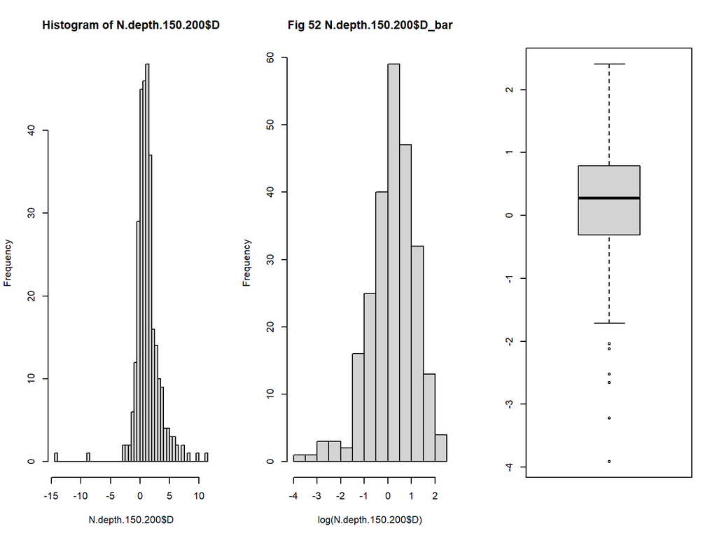

*Ndepth (150.200) is not very normal, but log transformation increases normality. Outliers present in box plot*

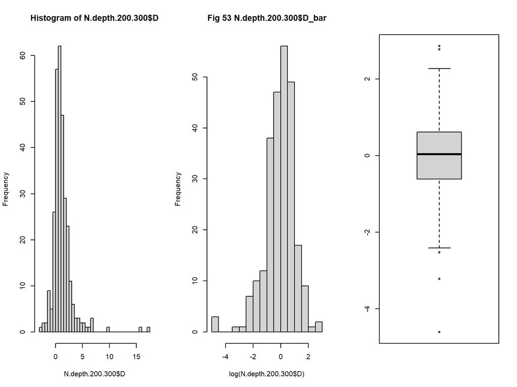

*Ndepth (200.300) is skewed, but log transformation increases normality. Outliers present in box plot*

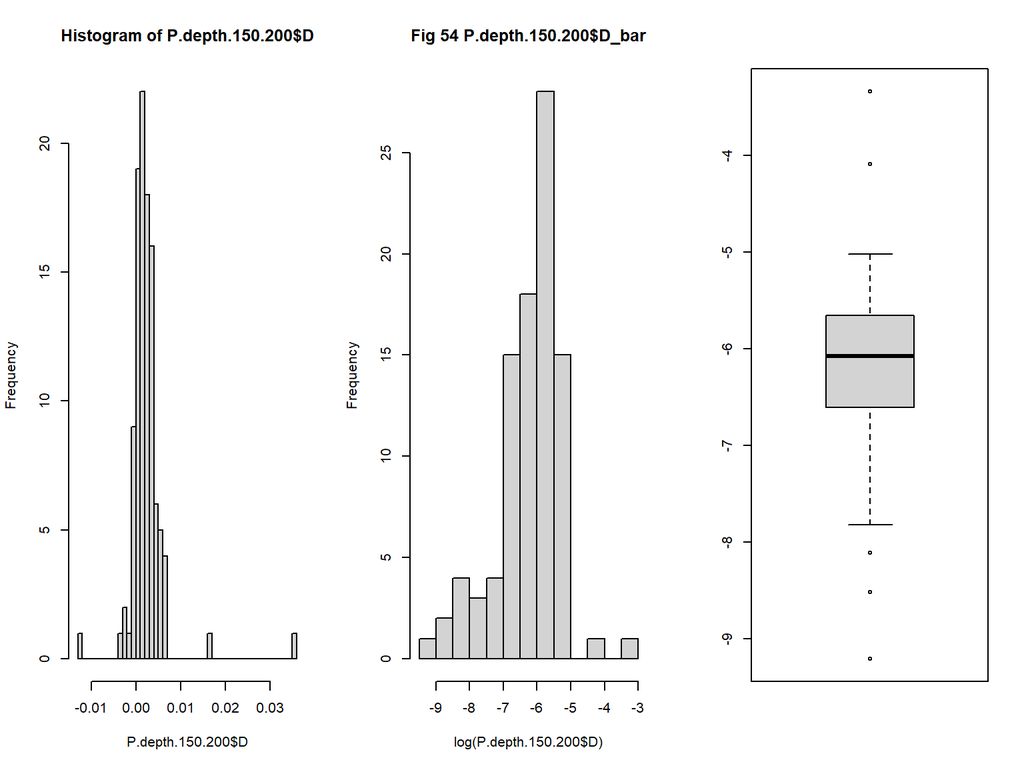

*Pdepth (150.200) is not very normal, but log transformation increases normality. Outliers present in box plot*

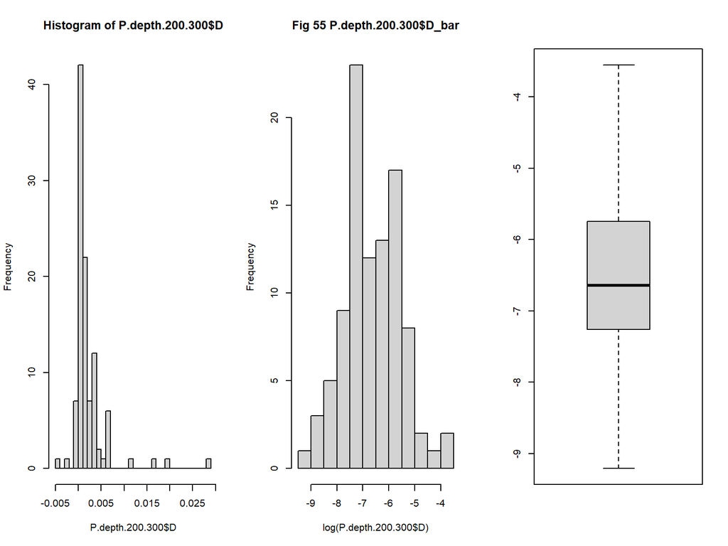

*Pdepth (200.300) is not very normal, but log transformation increases normality. NO outliers present in box plot*

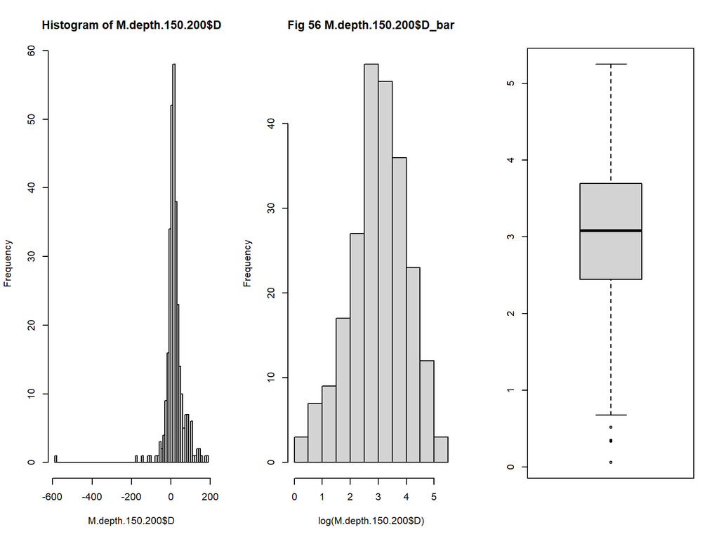

*Mdepth (150.200) is fairly normal, but log transformation increases normality. Outliers present in box plot*

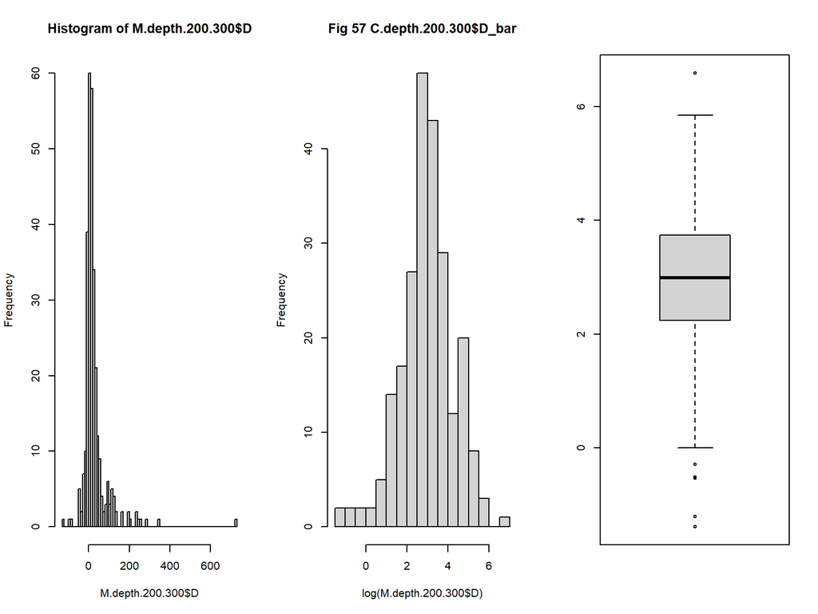

*Mdepth (200.300) is not normal, but log transformation increases normality. Outliers present in box plot*

Proceed with hypothesis test of log transformed data

#### Hyp 1

$\mu_1$ = mean Carbon flux at depth 150 $\mu_2$ = mean Carbon flux at depth 200

$H_0$ : Carbon flux does not change between 150 and 200 meter. $\mu_1$ = $\mu_2$ $H_1$ : Carbon flux is lower at 200 meter then at 150 meter. $\mu_1$ > $\mu_2$

```
##
##  Paired t-test
##
## data:  log(C.depth.150.200$C_avg.150) and log(C.depth.150.200$C_avg.200)
## t = 14.668, df = 302, p-value < 2.2e-16
## alternative hypothesis: true difference in means is greater than 0
## 95 percent confidence interval:
##  0.2578256       Inf
## sample estimates:
## mean of the differences
##               0.2905015
```

*super low p-value,significant, reject the null*

#### Hyp 2

$\mu_1$ = mean Carbon flux at depth 200 $\mu_2$ = mean Carbon flux at depth 300

$H_0$ : Carbon flux does not change between 200 and 300 meter. $\mu_1$ = $\mu_2$ $H_1$ : Carbon flux is lower at 300 meter then at 200 meter. $\mu_1$ > $\mu_2$

```
##
##  Paired t-test
##
## data:  log(C.depth.200.300$C_avg.200) and log(C.depth.200.300$C_avg.300)
## t = 13.324, df = 299, p-value < 2.2e-16
## alternative hypothesis: true difference in means is greater than 0
## 95 percent confidence interval:
##  0.3254642       Inf
## sample estimates:
## mean of the differences
##               0.3714623
```

*very low pval. We reject the null, significant*

#### Hyp 3

$\mu_1$ = mean Nitrogen flux at depth 150 $\mu_2$ = mean Nitrogen flux at depth 200

$H_0$ : Nitrogen flux does not change between 150 and 200 meter. $\mu_1$ = $\mu_2$ $H_1$ : Nitrogen flux is lower at 200 meter then at 150 meter. $\mu_1$ > $\mu_2$

```
##
##  Paired t-test
##
## data:  log(N.depth.150.200$N_avg.150) and log(N.depth.150.200$N_avg.200)
## t = 14.918, df = 300, p-value < 2.2e-16
## alternative hypothesis: true difference in means is greater than 0
## 95 percent confidence interval:
##  0.3202794       Inf
## sample estimates:
## mean of the differences
##                0.360109
```

*super low p-value,significant, reject the null*

#### Hyp 4

$\mu_1$ = mean Nitrogen flux at depth 200 $\mu_2$ = mean Nitrogen flux at depth 300

$H_0$ : Nitrogen flux does not change between 200 and 300 meter. $\mu_1$ = $\mu_2$ $H_1$ : Nitrogen flux is lower at 300 meter then at 200 meter. $\mu_1$ > $\mu_2$

```
##
##  Paired t-test
##
## data:  log(N.depth.200.300$N_avg.200) and log(N.depth.200.300$N_avg.300)
## t = 15.938, df = 297, p-value < 2.2e-16
## alternative hypothesis: true difference in means is greater than 0
## 95 percent confidence interval:
##  0.4047791       Inf
## sample estimates:
## mean of the differences
##               0.4515234
```

*super low p-value,significant, reject the null*

#### Hyp 5

$\mu_1$ = mean Phosporous flux at depth 150 $\mu_2$ = mean Phosporous flux at depth 200

$H_0$ : Phosporous flux does not change between 150 and 200 meter. $\mu_1$ = $\mu_2$ $H_1$ : Phosporous flux is lower at 200 meter then at 150 meter. $\mu_1$ > $\mu_2$

```
##
##  Paired t-test
##
## data:  log(P.depth.150.200$P_avg.150) and log(P.depth.150.200$P_avg.200)
## t = 10.941, df = 105, p-value < 2.2e-16
## alternative hypothesis: true difference in means is greater than 0
## 95 percent confidence interval:
##  0.3862101       Inf
## sample estimates:
## mean of the differences
##               0.4552613
```

*super low p-value,significant, reject the null*

#### Hyp 6

$\mu_1$ = mean Phosporous flux at depth 200 $\mu_2$ = mean Phosporous flux at depth 300

$H_0$ : Phosporous flux does not change between 200 and 300 meter. $\mu_1$ = $\mu_2$ $H_1$ : Phosporous flux is lower at 300 meter then at 200 meter. $\mu_1$ > $\mu_2$

```
##
##  Paired t-test
##
## data:  log(P.depth.200.300$P_avg.200) and log(P.depth.200.300$P_avg.300)
## t = 12.446, df = 104, p-value < 2.2e-16
## alternative hypothesis: true difference in means is greater than 0
## 95 percent confidence interval:
##  0.4504533       Inf
## sample estimates:
## mean of the differences
##               0.5197648
```

*super low p-value,significant, reject the null*

#### Hyp 7

$\mu_1$ = mean Mass flux at depth 150 $\mu_2$ = mean Mass flux at depth 200

$H_0$ : Mass flux does not change between 150 and 200 meter. $\mu_1$ = $\mu_2$ $H_1$ : Mass flux is lower at 200 meter then at 150 meter. $\mu_1$ > $\mu_2$

```
##
##  Paired t-test
##
## data:  log(M.depth.150.200$M_avg.150) and log(M.depth.150.200$M_avg.200)
## t = 11.049, df = 303, p-value < 2.2e-16
## alternative hypothesis: true difference in means is greater than 0
## 95 percent confidence interval:
##  0.1613635       Inf
## sample estimates:
## mean of the differences
##               0.1896883
```

*super low p-value,significant, reject the null*

#### Hyp 8

$\mu_1$ = mean Mass flux at depth 200 $\mu_2$ = mean Mass flux at depth 300

$H_0$ : Mass flux does not change between 200 and 300 meter. $\mu_1$ = $\mu_2$ $H_1$ : Mass flux is lower at 300 meter then at 200 meter. $\mu_1$ > $\mu_2$

```
##
##  Paired t-test
##
## data:  log(M.depth.200.300$M_avg.200) and log(M.depth.200.300$M_avg.300)
## t = 12.054, df = 300, p-value < 2.2e-16
## alternative hypothesis: true difference in means is greater than 0
## 95 percent confidence interval:
##  0.2143744       Inf
## sample estimates:
## mean of the differences
##               0.2483726
```

*super low p-value,significant, reject the null*

### Simple Linear Regression via LS

How does each flux predict Mass Flux?

Regression Model: $Y_i$ = $\beta_0$ + $\beta_1x_i$ + $\epsilon_i$ where $\epsilon_i$ ~ $N(0,\sigma^2)$

Best Fit line: $f(x)$ = $\hat{\beta_0}$ + $\hat{\beta_1}x$

```
##
## Call:
## lm(formula = log(M_avg) ~ log(C_avg), data = Data.noNA)
##
## Residuals:
##      Min       1Q   Median       3Q      Max
## -0.83440 -0.25212 -0.04393  0.18902  2.05452
##
## Coefficients:
##             Estimate Std. Error t value Pr(>|t|)
## (Intercept)  2.00513    0.08106   24.74   <2e-16 ***
## log(C_avg)   0.83365    0.02835   29.41   <2e-16 ***
## ---
## Signif. codes:  0 '***' 0.001 '**' 0.01 '*' 0.05 '.' 0.1 ' ' 1
##
## Residual standard error: 0.3784 on 303 degrees of freedom
## Multiple R-squared:  0.7405, Adjusted R-squared:  0.7396
## F-statistic: 864.6 on 1 and 303 DF,  p-value: < 2.2e-16
```

```
##
## Call:
## lm(formula = log(M_avg) ~ log(N_avg), data = Data.noNA)
##
## Residuals:
##      Min       1Q   Median       3Q      Max
## -0.96805 -0.31451 -0.06096  0.25532  1.77284
##
## Coefficients:
##             Estimate Std. Error t value Pr(>|t|)
## (Intercept)  3.58148    0.03984   89.89   <2e-16 ***
## log(N_avg)   0.76636    0.03269   23.44   <2e-16 ***
## ---
## Signif. codes:  0 '***' 0.001 '**' 0.01 '*' 0.05 '.' 0.1 ' ' 1
##
## Residual standard error: 0.4429 on 303 degrees of freedom
## Multiple R-squared:  0.6446, Adjusted R-squared:  0.6434
## F-statistic: 549.6 on 1 and 303 DF,  p-value: < 2.2e-16
```

```
##
## Call:
## lm(formula = log(M_avg) ~ log(P_avg), data = Data.noNA)
##
## Residuals:
##      Min       1Q   Median       3Q      Max
## -2.47045 -0.37370 -0.05109  0.33124  2.41221
##
## Coefficients:
##             Estimate Std. Error t value Pr(>|t|)
## (Intercept)  6.86337    0.19945   34.41   <2e-16 ***
## log(P_avg)   0.45385    0.03482   13.03   <2e-16 ***
## ---
## Signif. codes:  0 '***' 0.001 '**' 0.01 '*' 0.05 '.' 0.1 ' ' 1
##
## Residual standard error: 0.5946 on 303 degrees of freedom
## Multiple R-squared:  0.3592, Adjusted R-squared:  0.3571
## F-statistic: 169.9 on 1 and 303 DF,  p-value: < 2.2e-16
```

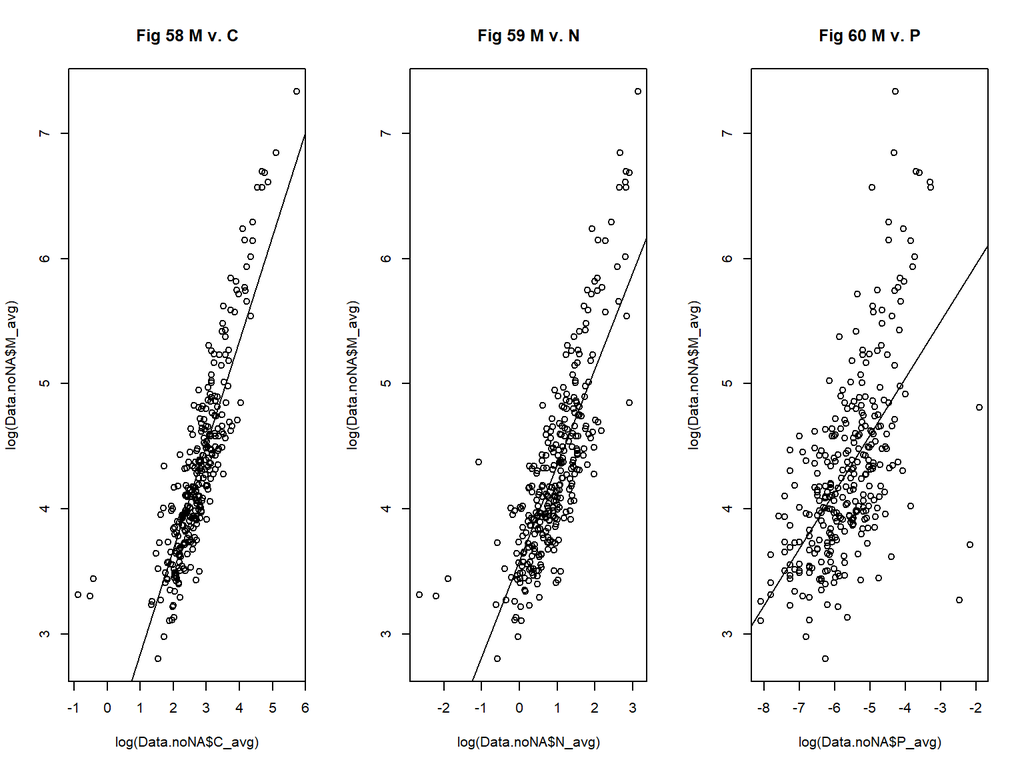

*Both predictor and predictee had to be log transformed in order to make this data more linear with less clumping for all fluxes*

*For C flux, multilple r squared is 0.7405, so pretty good fit. Some clumping still*

*For N flux, multiple r squared is 0.6446, so still pretty decent, just not as strong as C flux. Some clumping still*

*For P flux, multiple r squared is 0.3592, so very poor fit and a lot of clumping*

Carbon flux seems to be the best predictor of Mass flux. Lets run some EDA.

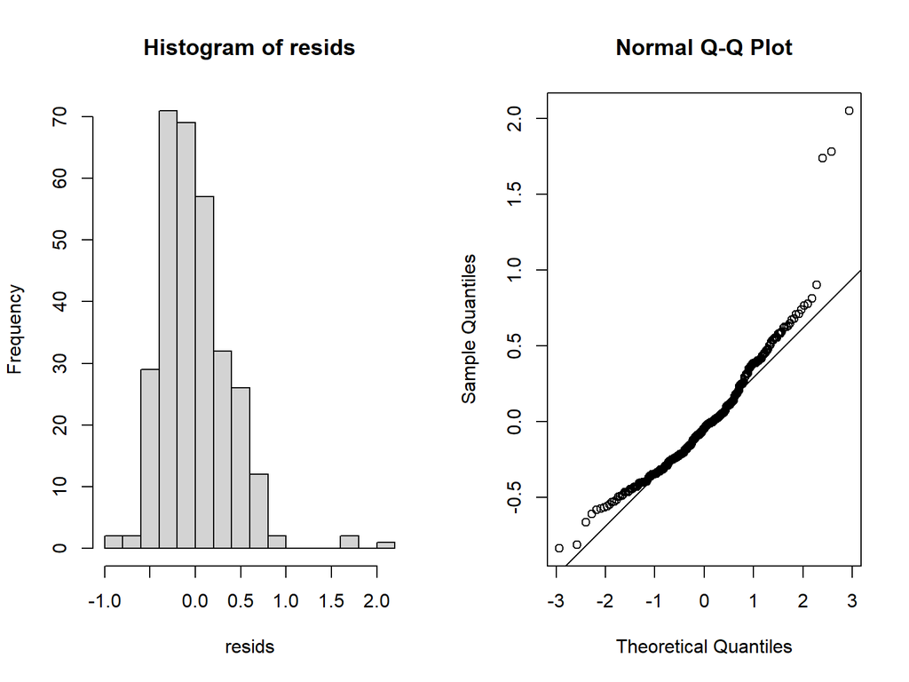

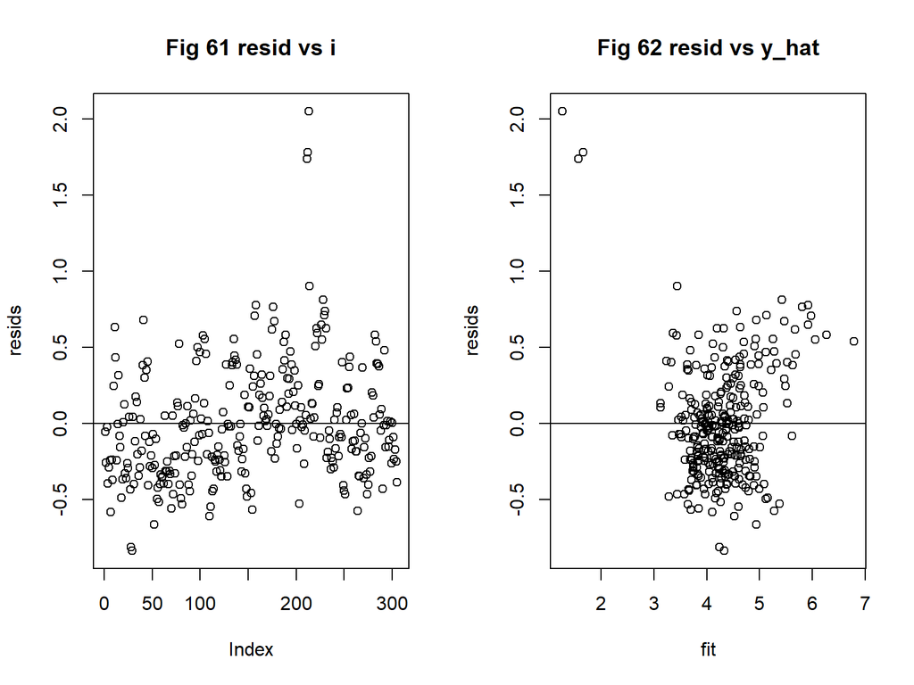

*Not very normal, linearity is okay, but not great, both residual are not very evenly scattered and there is clumping around the line, so not heteroscedasicity, trifecta is broken*

Lets compare these EDA’s to that of Nitrogen Flux and Mass Flux. Nitrogen Flux was also a strong predictor of Mass Flux.

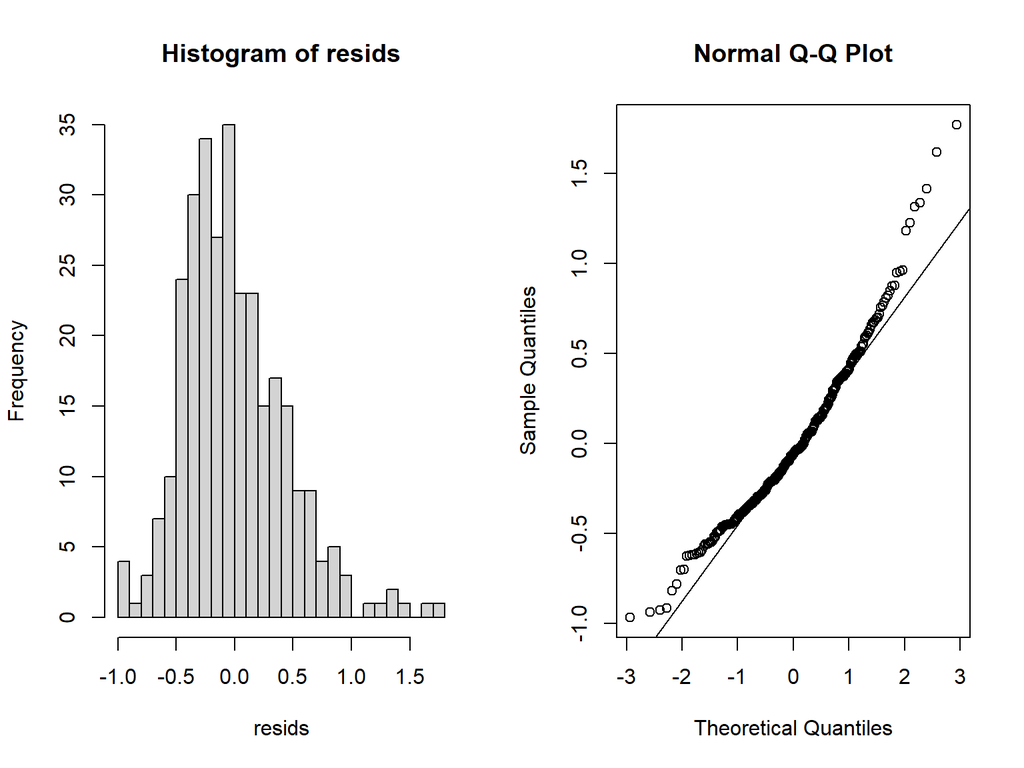

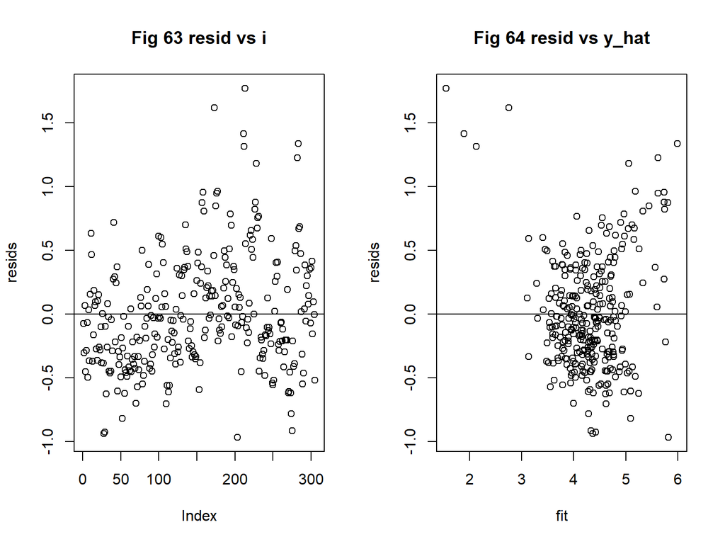

*Not very normal, linearity is okay, but not great, both residual are not very evenly scattered and there is clumping around the line, so not heteroscedasicity, trifecta is broken about the same as C flux*

Lets now compare these to Phosphorous Flux, a weak predcitor of Mass Flux.

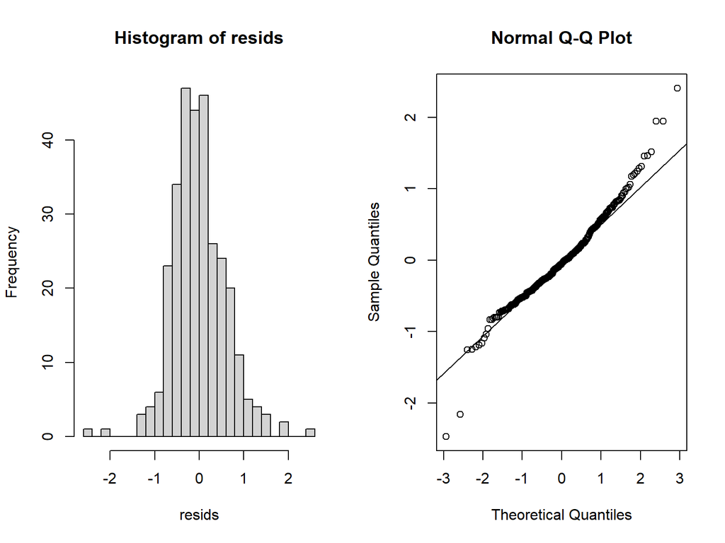

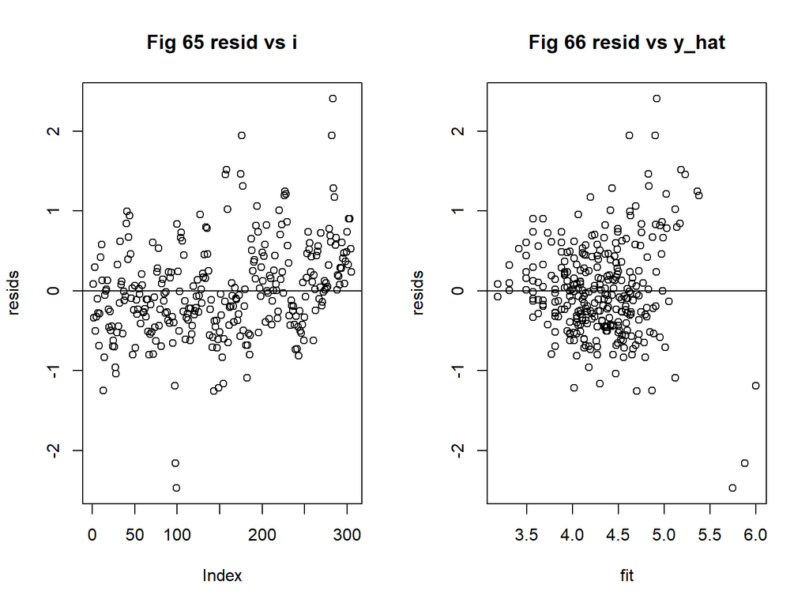

*Somewhat normal, linearity is okay, but not great, both residual are not very evenly scattered and there is clumping around the line, so not heteroscedasicity, trifecta is broken*

Do we see collinearity between the different fluxes that are predicting mass flux? Should we combine the fluxes?

Regression Model: $Y_i$ = $\beta_0$ + $\beta_1x_i$ + $\epsilon_i$ where $\epsilon_i$ ~ $N(0,\sigma^2)$